# VAR Predictability Benchmark

## 3.2 Raw-Scale MSE (S4)

Here, we increase iterations due to some convergence issues.

```r
model_path <- here::here("output", "analysis", "fit_relmse_s4.rds")

# all models including the mean model, so the reference is modelled instead of divided out
df_raw <- df_meta |>
  dplyr::filter(set == "oos", is.finite(gm_mse), gm_mse > 0)

# raw MSE on the [0, 1] scale is around exp(-3), not 1
priors_raw <- c(
  prior(normal(-3, 2), class = b),
  prior(exponential(2), class = sd),
  prior(normal(-1, 1), class = b, dpar = sigma),
  prior(gamma(2, 0.1), class = nu)
)

if (refit_models || !file.exists(model_path)) {
  fit_relmse_s4 <- brm(
    bf(log(gm_mse) ~ 0 + model + (1 | dataset_id) + (1 | dataset_id:model) + (1 | unique_id),
       sigma ~ 0 + model),
    data = df_raw,
    family = student(),
    prior = priors_raw,
    chains = 4,
    cores = 4,
    iter = 6000,
    warmup = 2000,
    seed = seed,
    refresh = 0,
    silent = 2
  )

  saveRDS(fit_relmse_s4, model_path)
} else {
  fit_relmse_s4 <- read_fit(model_path, "student")
}
```

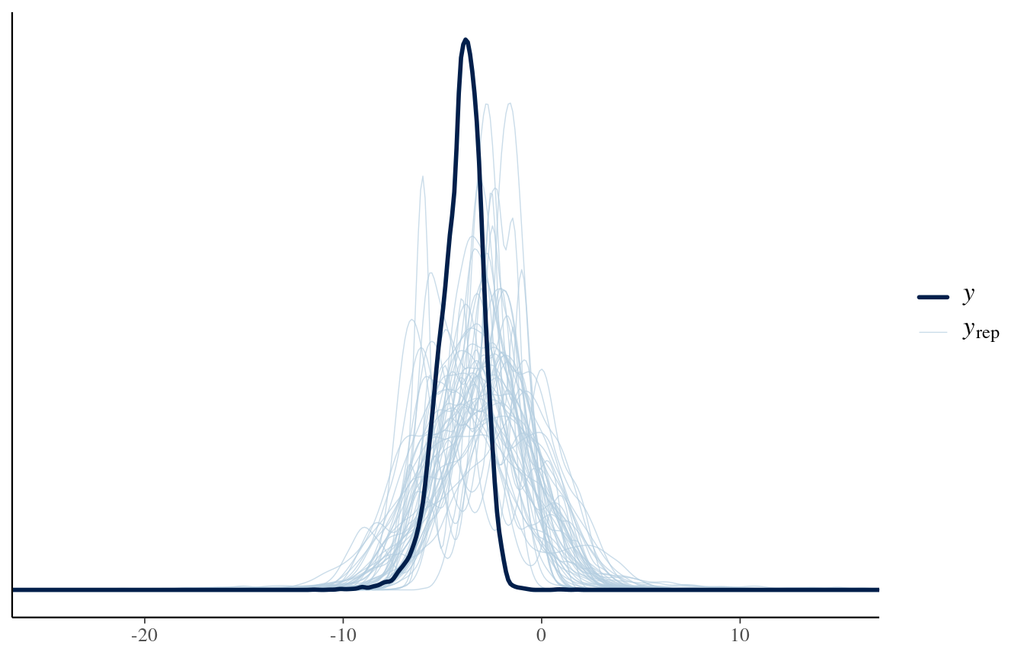

```r
model_path <- here::here("output", "analysis", "fit_relmse_s4_prior.rds")

if (refit_models || !file.exists(model_path)) {
  fit_relmse_s4_prior <- update(fit_relmse_s4, sample_prior = "only", seed = seed,
    refresh = 0, silent = 2)
  saveRDS(fit_relmse_s4_prior, model_path)
} else {
  fit_relmse_s4_prior <- read_fit(model_path, "student")
}

prior_check(fit_relmse_s4_prior)
```

```r
parameters::model_parameters(fit_relmse_s4, test = "pd")
```

```
# Fixed Effects

Parameter      | Median |         95% CI |   pd |  Rhat | ESS (tail)
--------------------------------------------------------------------
modelmean      |  -4.05 | [-4.26, -3.83] | 100% | 1.003 |       2614
modelnaive     |  -3.81 | [-4.03, -3.60] | 100% | 1.003 |       2763
modeltrend     |  -4.05 | [-4.26, -3.83] | 100% | 1.003 |       2611
modelri        |  -4.02 | [-4.23, -3.80] | 100% | 1.004 |       2507
modelar        |  -4.12 | [-4.34, -3.91] | 100% | 1.003 |       2504
modelvar       |  -3.87 | [-4.08, -3.66] | 100% | 1.004 |       2514
modellasso_var |  -4.08 | [-4.29, -3.86] | 100% | 1.004 |       2678
modelml_ar     |  -4.14 | [-4.35, -3.92] | 100% | 1.003 |       2675
modelml_var    |  -4.13 | [-4.34, -3.91] | 100% | 1.003 |       2334

# sigma Parameters

Parameter      | Median |         95% CI |   pd |  Rhat | ESS (tail)
--------------------------------------------------------------------
modelmean      |  -2.31 | [-2.38, -2.25] | 100% | 1.002 |      11510
modelnaive     |  -1.67 | [-1.73, -1.60] | 100% | 1.000 |       9759
modeltrend     |  -1.65 | [-1.72, -1.59] | 100% | 1.000 |      10894
modelri        |  -2.29 | [-2.35, -2.22] | 100% | 1.001 |      11008
modelar        |  -3.58 | [-3.68, -3.49] | 100% | 1.005 |       9878
modelvar       |  -2.01 | [-2.07, -1.94] | 100% | 1.004 |      11409
modellasso_var |  -2.76 | [-2.83, -2.69] | 100% | 1.003 |       9819
modelml_ar     |  -4.02 | [-4.16, -3.90] | 100% | 1.003 |       5067
modelml_var    |  -2.94 | [-3.01, -2.87] | 100% | 1.001 |      10569
```

Posterior predictive checks of S4:

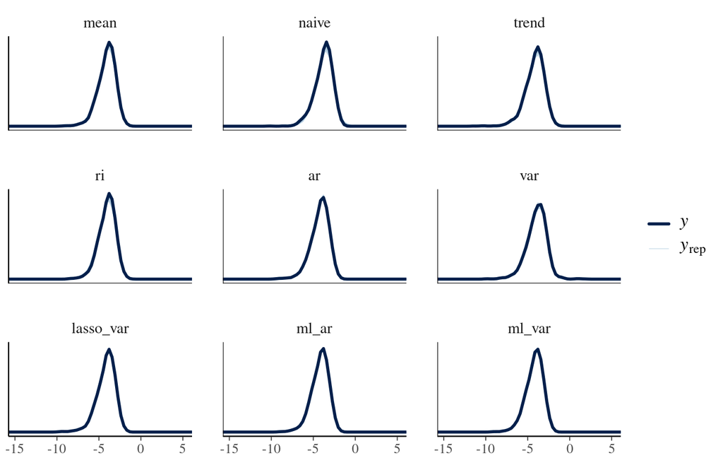

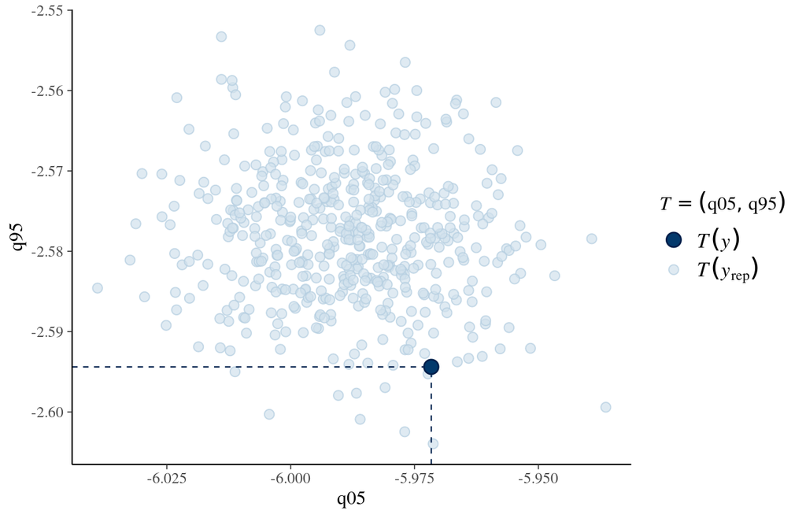

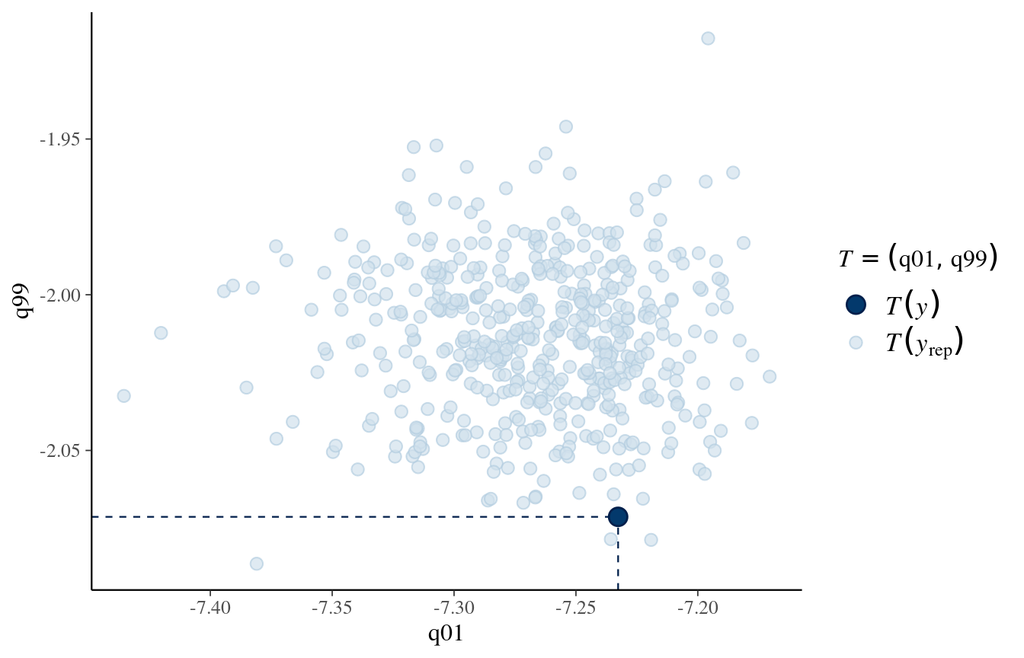

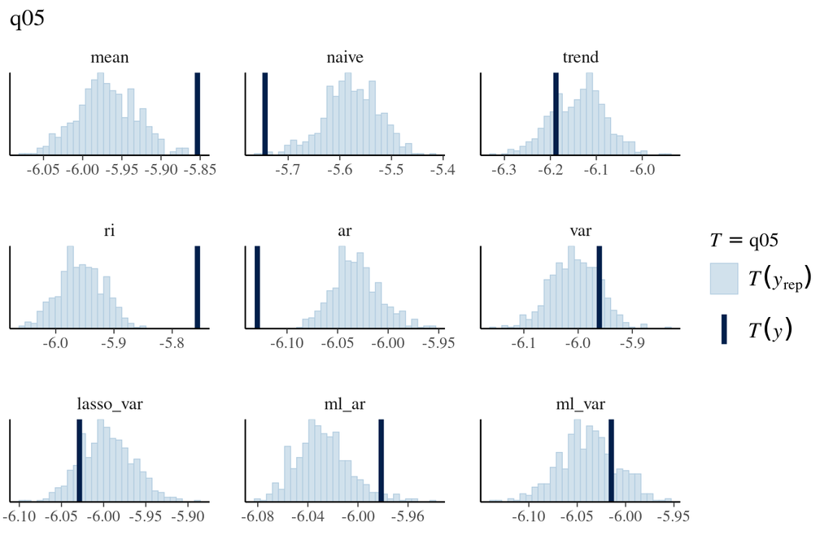

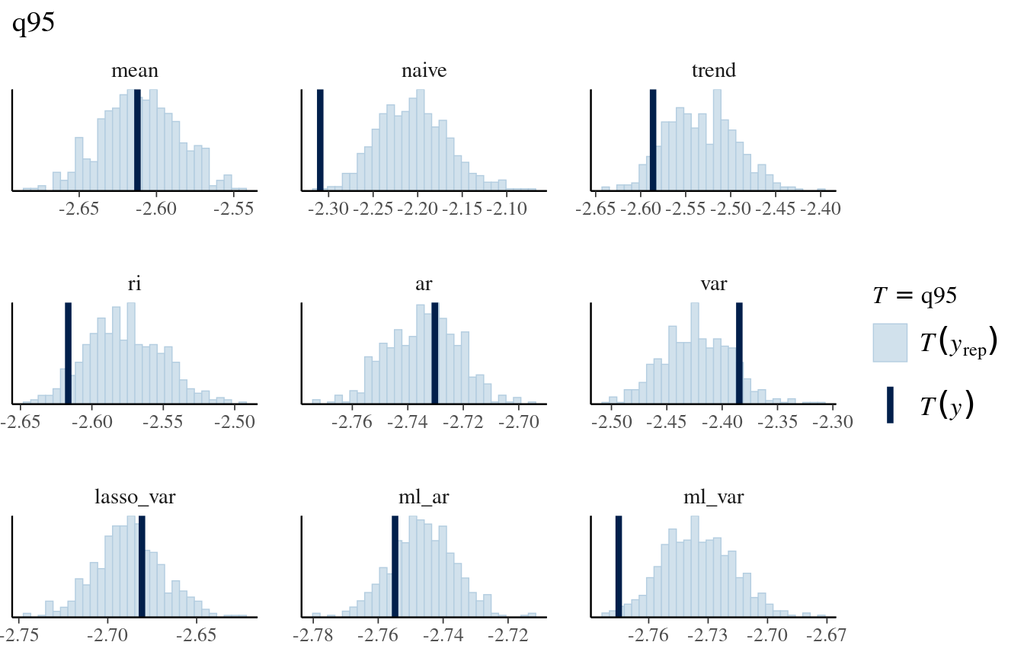

```r
posterior_checks(fit_relmse_s4)
```

# 4 Convergence Diagnostics

```r
# population-level and variance parameters only. the person-level effects are too many to list
convergence <- function(fit) {
  draws <- brms::as_draws_df(fit, variable = "^(b_|sd_|nu$)", regex = TRUE)
  summary <- posterior::summarise_draws(draws, "rhat", "ess_bulk", "ess_tail")
  nuts <- brms::nuts_params(fit)
  tibble::tibble(
    max_rhat = max(summary$rhat),
    min_ess_bulk = min(summary$ess_bulk),
    min_ess_tail = min(summary$ess_tail),
    divergences = sum(nuts$Value[nuts$Parameter == "divergent__"])
  )
}

list(M1 = fit_relmse_m1, M1b = fit_relmse_m1b, M2 = fit_relmse_m2, M3 = fit_relmse_m3,
     S1 = fit_relmse_s1, S4 = fit_relmse_s4) |>
  lapply(convergence) |>
  dplyr::bind_rows(.id = "model") |>
  pander::pander(digits = 3, caption = "Convergence diagnostics per fitted model.")
```

Convergence diagnostics per fitted model.

| model | max_rhat | min_ess_bulk | min_ess_tail | divergences |
| --- | --- | --- | --- | --- |
| M1 | 1.01 | 839 | 1153 | 0 |
| M1b | 1.01 | 616 | 1154 | 0 |
| M2 | 1.01 | 654 | 1126 | 0 |
| M3 | 1.01 | 340 | 486 | 0 |
| S1 | 1.01 | 652 | 1191 | 0 |
| S4 | 1.03 | 370 | 966 | 0 |

# 5 Computation Times

Stan stores the warmup and sampling time of each chain in the fitted model, so the computation times can be read from the cached fits without refitting. They do not include the compilation of the Stan models. The four chains of a model run in parallel on separate cores: the sampling time adds up all chains, and the elapsed time is that of the slowest chain. The prior predictive models are listed separately.

```r
meta_fits <- list(
  M1 = fit_relmse_m1, M1b = fit_relmse_m1b, M2 = fit_relmse_m2, M3 = fit_relmse_m3,
  S1 = fit_relmse_s1, S4 = fit_relmse_s4,
  `M1 prior` = fit_relmse_m1_prior, `M2 prior` = fit_relmse_m2_prior,
  `M3 prior` = fit_relmse_m3_prior, `S1 prior` = fit_relmse_s1_prior,
  `S4 prior` = fit_relmse_s4_prior
)

# seconds per chain, one column each for warmup and sampling
meta_times <- lapply(meta_fits, function(fit) {
  chain_sec <- rstan::get_elapsed_time(fit$fit)
  tibble::tibble(chains = nrow(chain_sec), sampling_sec = sum(chain_sec),
                 elapsed_sec = max(rowSums(chain_sec)))
}) |>
  dplyr::bind_rows(.id = "model") |>
  dplyr::mutate(prior_only = grepl("prior$", model))

meta_times |>
  dplyr::mutate(sampling_min = sampling_sec / 60, elapsed_min = elapsed_sec / 60) |>
  dplyr::select(model, chains, sampling_min, elapsed_min) |>
  pander::pander(digits = 3, caption = "Sampling time of the meta-models in minutes.")
```

Sampling time of the meta-models in minutes.

| model | chains | sampling_min | elapsed_min |
| --- | --- | --- | --- |
| M1 | 4 | 123 | 31.9 |
| M1b | 4 | 192 | 58.7 |
| M2 | 4 | 124 | 31.7 |
| M3 | 4 | 134 | 34.9 |
| S1 | 4 | 60.9 | 15.6 |
| S4 | 4 | 893 | 230 |
| M1 prior | 4 | 0.239 | 0.06 |
| M2 prior | 4 | 0.271 | 0.0908 |
| M3 prior | 4 | 0.25 | 0.0627 |
| S1 prior | 4 | 0.238 | 0.0599 |
| S4 prior | 4 | 0.483 | 0.121 |

```r
meta_with_data <- dplyr::filter(meta_times, !prior_only)
slowest_meta <- dplyr::slice_max(meta_with_data, elapsed_sec, n = 1, with_ties = FALSE)
```

Sampling the 6 meta-models with data took 1527 minutes in total, summed over all chains, and 403 minutes of elapsed time when the models are fitted one after another with parallel chains. The slowest model was S4 (230 minutes elapsed). The prior predictive models added 1 minutes of sampling time.

**R version 4.6.2 (2026-10-29)**

**Platform:** x86_64-pc-linux-gnu

**locale:** *LC_CTYPE=de_DE.UTF-8*, *LC_NUMERIC=C*, *LC_TIME=de_DE.UTF-8*, *LC_COLLATE=de_DE.UTF-8*, *LC_MONETARY=de_DE.UTF-8*, *LC_MESSAGES=de_DE.UTF-8*, *LC_PAPER=de_DE.UTF-8*, *LC_NAME=C*, *LC_ADDRESS=C*, *LC_TELEPHONE=C*, *LC_MEASUREMENT=de_DE.UTF-8* and *LC_IDENTIFICATION=C*

**attached base packages:** *stats*, *graphics*, *grDevices*, *datasets*, *utils*, *methods* and *base*

**other attached packages:** *bayesplot(v.1.16.0)*, *parameters(v.0.29.3)*, *pander(v.0.6.6)*, *brms(v.2.23.0)*, *Rcpp(v.1.1.2)*, *dplyr(v.1.2.1)*, *tibble(v.3.3.1)* and *here(v.1.0.2)*

**loaded via a namespace (and not attached):** *gtable(v.0.3.6)*, *tensorA(v.0.36.2.1)*, *xfun(v.0.60)*, *bayestestR(v.0.19.0)*, *ggplot2(v.4.0.3)*, *QuickJSR(v.1.11.0)*, *processx(v.3.9.0)*, *insight(v.1.5.4)*, *inline(v.0.3.21)*, *lattice(v.0.22-9)*, *callr(v.3.8.0)*, *ps(v.1.9.3)*, *Rdpack(v.2.6.6)*, *vctrs(v.0.7.3)*, *tools(v.4.6.2)*, *generics(v.0.1.4)*, *stats4(v.4.6.2)*, *parallel(v.4.6.2)*, *datawizard(v.1.4.0)*, *pkgconfig(v.2.0.3)*, *Matrix(v.1.7-5)*, *checkmate(v.2.3.4)*, *RColorBrewer(v.1.1-3)*, *S7(v.0.2.2)*, *distributional(v.0.9.0)*, *RcppParallel(v.6.2.1)*, *lifecycle(v.1.0.5)*, *compiler(v.4.6.2)*, *farver(v.2.1.2)*, *stringr(v.1.6.0)*, *Brobdingnag(v.1.3-1)*, *codetools(v.0.2-20)*, *htmltools(v.0.5.9)*, *yaml(v.2.3.12)*, *pillar(v.1.11.1)*, *reformulas(v.0.4.4)*, *StanHeaders(v.2.39.1)*, *bridgesampling(v.1.2-1)*, *abind(v.1.4-8)*, *nlme(v.3.1-169)*, *posterior(v.1.7.0)*, *rstan(v.2.32.7)*, *tidyselect(v.1.2.1)*, *digest(v.0.6.39)*, *mvtnorm(v.1.4-2)*, *stringi(v.1.8.9)*, *reshape2(v.1.4.5)*, *labeling(v.0.4.3)*, *rprojroot(v.2.1.1)*, *fastmap(v.1.2.0)*, *grid(v.4.6.2)*, *cli(v.3.6.6)*, *magrittr(v.2.0.5)*, *loo(v.2.10.1)*, *pkgbuild(v.1.4.8)*, *withr(v.3.0.3)*, *scales(v.1.4.0)*, *backports(v.1.5.1)*, *rmarkdown(v.2.31)*, *matrixStats(v.1.5.0)*, *otel(v.0.2.0)*, *gridExtra(v.2.3.1)*, *coda(v.0.19-4.1)*, *evaluate(v.1.0.5)*, *knitr(v.1.51)*, *rbibutils(v.2.4.1)*, *rstantools(v.2.7.1)*, *rlang(v.1.3.0)*, *glue(v.1.8.1)*, *renv(v.1.2.3)*, *jsonlite(v.2.0.0)*, *plyr(v.1.8.9)* and *R6(v.2.6.1)*